# Predictive Modeling for Customer Loyalty and Retention in the Airline Industry

Objectives: Airline Industry is highly capital intensive in nature. With many factors affecting its profitability. The airline requires a certain certainity with regards to cash flow and revenue. This can be done by increasing customer loyalty to an airlines in teh form of frequent flyer program or other rewards program. We have to looak what are the factors which are important in order to increase customer loyalty.

Tables

Loyalty Number: Customers Unique Loyalty Number

Year: Year of the Period

Month: Month of the Period

Flights Booked: Number of Flights Booked for member only in the period

Flights with Companion: Number of Flights Booked with additional passengers in the period

Total Flights: Sum of Flights Booked and Flights with Companions

Distance: Flight Distance Traveled in the Period(Km)

Points Accumulated: Loyalty Points Accumulated in the period

Points Redeemed: Loyalty Points redeemed in the period

Dollar Cost Points Redeemed: Dollar Equivalent for points redeemed in the period in CDN

Country: Country of Residence

Province: Province of Residence

City: City of Residence

Postal Code: Postal code of residence

Gender: Gender

Education: Highest Education Level(High School or Lower > College> Bachelor>Master>Doctor)

Salary: Annual Income

Marital Status: Marital Status(Single, Married, Divorced)

Loyalty Card: Loyalty Card Status(Star > Nova > Aurora )

CLV: Customer Lifetime Value - Total Invoice Value for all flights ever booked by member

Enrollment Type: Enrollment Type(Standard/ Type 2018 Promotion)

Enrollment Year: Year Member Enrolled in membership program

Enrollment Month: Month Member enrolled in membership program

Cancellation Year: Year Cancelled their membership

Cancellation Month: Month Member Cancelled their membership

```python
import pandas as pd
import numpy as np
import seaborn as sns
import matplotlib.pyplot as plt
```

```python
df1 = pd.read_csv('Customer Flight Activity.csv')
```

```python
df2 = pd.read_csv('Customer Loyalty History.csv')
```

```python
df1.head()
```

|  | Loyalty Number | Year | Month | Flights Booked | Flights with Companions | Total Flights | Distance | Points Accumulated | Points Redeemed | Dollar Cost Points Redeemed |
| --- | --- | --- | --- | --- | --- | --- | --- | --- | --- | --- |
| 0 | 100018 | 2017 | 1 | 3 | 0 | 3 | 1521 | 152.0 | 0 | 0 |
| 1 | 100102 | 2017 | 1 | 10 | 4 | 14 | 2030 | 203.0 | 0 | 0 |
| 2 | 100140 | 2017 | 1 | 6 | 0 | 6 | 1200 | 120.0 | 0 | 0 |
| 3 | 100214 | 2017 | 1 | 0 | 0 | 0 | 0 | 0.0 | 0 | 0 |
| 4 | 100272 | 2017 | 1 | 0 | 0 | 0 | 0 | 0.0 | 0 | 0 |

```python
df2.head()
```

|  | Loyalty Number | Country | Province | City | Postal Code | Gender | Education | Salary | Marital Status | Loyalty Card | CLV | Enrollment Type | Enrollment Year | Enrollment Month | Cancellation Year | Cancellation Month |
| --- | --- | --- | --- | --- | --- | --- | --- | --- | --- | --- | --- | --- | --- | --- | --- | --- |
| 0 | 480934 | Canada | Ontario | Toronto | M2Z 4K1 | Female | Bachelor | 83236.0 | Married | Star | 3839.14 | Standard | 2016 | 2 | NaN | NaN |
| 1 | 549612 | Canada | Alberta | Edmonton | T3G 6Y6 | Male | College | NaN | Divorced | Star | 3839.61 | Standard | 2016 | 3 | NaN | NaN |
| 2 | 429460 | Canada | British Columbia | Vancouver | V6E 3D9 | Male | College | NaN | Single | Star | 3839.75 | Standard | 2014 | 7 | 2018.0 | 1.0 |
| 3 | 608370 | Canada | Ontario | Toronto | P1W 1K4 | Male | College | NaN | Single | Star | 3839.75 | Standard | 2013 | 2 | NaN | NaN |
| 4 | 530508 | Canada | Quebec | Hull | J8Y 3Z5 | Male | Bachelor | 103495.0 | Married | Star | 3842.79 | Standard | 2014 | 10 | NaN | NaN |

```python
### Merge Dataframe
m_df = pd.merge(df1,df2,on = 'Loyalty Number')
```

```python
m_df.head()
```

|  | Loyalty Number | Year | Month | Flights Booked | Flights with Companions | Total Flights | Distance | Points Accumulated | Points Redeemed | Dollar Cost Points Redeemed | ... | Education | Salary | Marital Status | Loyalty Card | CLV | Enrollment Type | Enrollment Year | Enrollment Month | Cancellation Year | Cancellation Month |
| --- | --- | --- | --- | --- | --- | --- | --- | --- | --- | --- | --- | --- | --- | --- | --- | --- | --- | --- | --- | --- | --- |
| 0 | 100018 | 2017 | 1 | 3 | 0 | 3 | 1521 | 152.0 | 0 | 0 | ... | Bachelor | 92552.0 | Married | Aurora | 7919.2 | Standard | 2016 | 8 | NaN | NaN |
| 1 | 100018 | 2017 | 2 | 2 | 2 | 4 | 1320 | 132.0 | 0 | 0 | ... | Bachelor | 92552.0 | Married | Aurora | 7919.2 | Standard | 2016 | 8 | NaN | NaN |
| 2 | 100018 | 2018 | 10 | 6 | 4 | 10 | 3110 | 311.0 | 385 | 31 | ... | Bachelor | 92552.0 | Married | Aurora | 7919.2 | Standard | 2016 | 8 | NaN | NaN |
| 3 | 100018 | 2017 | 4 | 4 | 0 | 4 | 924 | 92.0 | 0 | 0 | ... | Bachelor | 92552.0 | Married | Aurora | 7919.2 | Standard | 2016 | 8 | NaN | NaN |
| 4 | 100018 | 2017 | 5 | 0 | 0 | 0 | 0 | 0.0 | 0 | 0 | ... | Bachelor | 92552.0 | Married | Aurora | 7919.2 | Standard | 2016 | 8 | NaN | NaN |

5 rows × 25 columns

```python
m_df.shape
```

```
(405624, 25)
```

```python
m_df.describe()
```

|  | Loyalty Number | Year | Month | Flights Booked | Flights with Companions | Total Flights | Distance | Points Accumulated | Points Redeemed | Dollar Cost Points Redeemed | Salary | CLV | Enrollment Year | Enrollment Month | Cancellation Year | Cancellation Month |
| --- | --- | --- | --- | --- | --- | --- | --- | --- | --- | --- | --- | --- | --- | --- | --- | --- |
| count | 405624.000000 | 405624.000000 | 405624.000000 | 405624.000000 | 405624.000000 | 405624.000000 | 405624.000000 | 405624.000000 | 405624.000000 | 405624.000000 | 302952.000000 | 405624.000000 | 405624.000000 | 405624.000000 | 50064.000000 | 50064.000000 |
| mean | 550037.873084 | 2017.500000 | 6.500000 | 4.115052 | 1.031805 | 5.146858 | 1208.880059 | 123.692721 | 30.696872 | 2.484503 | 79268.825953 | 7991.976226 | 2015.252529 | 6.668008 | 2016.499521 | 6.966443 |
| std | 258935.286969 | 0.500001 | 3.452057 | 5.225518 | 2.076869 | 6.521227 | 1433.155320 | 146.599831 | 125.486049 | 10.150038 | 34992.133508 | 6863.663857 | 1.979427 | 3.399766 | 1.384336 | 3.448300 |
| min | 100018.000000 | 2017.000000 | 1.000000 | 0.000000 | 0.000000 | 0.000000 | 0.000000 | 0.000000 | 0.000000 | 0.000000 | -58486.000000 | 1898.010000 | 2012.000000 | 1.000000 | 2013.000000 | 1.000000 |
| 25% | 326961.000000 | 2017.000000 | 3.750000 | 0.000000 | 0.000000 | 0.000000 | 0.000000 | 0.000000 | 0.000000 | 0.000000 | 59262.000000 | 3985.320000 | 2014.000000 | 4.000000 | 2016.000000 | 4.000000 |
| 50% | 550834.000000 | 2017.500000 | 6.500000 | 1.000000 | 0.000000 | 1.000000 | 488.000000 | 50.000000 | 0.000000 | 0.000000 | 73479.000000 | 5776.340000 | 2015.000000 | 7.000000 | 2017.000000 | 7.000000 |
| 75% | 772194.000000 | 2018.000000 | 9.250000 | 8.000000 | 1.000000 | 10.000000 | 2336.000000 | 239.000000 | 0.000000 | 0.000000 | 88612.000000 | 8936.820000 | 2017.000000 | 10.000000 | 2018.000000 | 10.000000 |
| max | 999986.000000 | 2018.000000 | 12.000000 | 21.000000 | 11.000000 | 32.000000 | 6293.000000 | 676.500000 | 876.000000 | 71.000000 | 407228.000000 | 83325.380000 | 2018.000000 | 12.000000 | 2018.000000 | 12.000000 |

```python
m_df.isnull().sum()
```

```
Loyalty Number                      0
Year                                0
Month                               0
Flights Booked                      0
Flights with Companions             0
Total Flights                       0
Distance                            0
Points Accumulated                  0
Points Redeemed                     0
Dollar Cost Points Redeemed         0
Country                             0
Province                            0
City                                0
Postal Code                         0
Gender                              0
Education                           0
Salary                         102672
Marital Status                      0
Loyalty Card                        0
CLV                                 0
Enrollment Type                     0
Enrollment Year                     0
Enrollment Month                    0
Cancellation Year              355560
Cancellation Month             355560
dtype: int64
```

```python
m_df.info()
```

```
<class 'pandas.core.frame.DataFrame'>
Int64Index: 405624 entries, 0 to 405623
Data columns (total 25 columns):
 #   Column                       Non-Null Count   Dtype
---  ------                       --------------   -----
 0   Loyalty Number               405624 non-null  int64
 1   Year                         405624 non-null  int64
 2   Month                        405624 non-null  int64
 3   Flights Booked               405624 non-null  int64
 4   Flights with Companions      405624 non-null  int64
 5   Total Flights                405624 non-null  int64
 6   Distance                     405624 non-null  int64
 7   Points Accumulated           405624 non-null  float64
 8   Points Redeemed              405624 non-null  int64
 9   Dollar Cost Points Redeemed  405624 non-null  int64
```

[output cut: 17 more lines]

```python
print("There are total of 25 columns")
df_cat = m_df.select_dtypes(include=np.object)
df_num = m_df.select_dtypes(include=np.number)
print("Total Categorical Columns: ", len(df_cat.columns))
print('\n')
print('Categorical column names : ',df_cat.columns)
print('\n')
print('Total numerical columns : ',len(df_num.columns))
print('\n')
print('Numerical column names : ',df_num.columns)
```

```
There are total of 25 columns
```

```
Total Categorical Columns:  9


Categorical column names :  Index(['Country', 'Province', 'City', 'Postal Code', 'Gender', 'Education',
       'Marital Status', 'Loyalty Card', 'Enrollment Type'],
      dtype='object')


Total numerical columns :  16


Numerical column names :  Index(['Loyalty Number', 'Year', 'Month', 'Flights Booked',
       'Flights with Companions', 'Total Flights', 'Distance',
       'Points Accumulated', 'Points Redeemed', 'Dollar Cost Points Redeemed',
       'Salary', 'CLV', 'Enrollment Year', 'Enrollment Month',
       'Cancellation Year', 'Cancellation Month'],
      dtype='object')
```

```python
### Data Cleaning and Preprocessing
df1 = m_df.copy()
```

```python
df1.head()
```

|  | Loyalty Number | Year | Month | Flights Booked | Flights with Companions | Total Flights | Distance | Points Accumulated | Points Redeemed | Dollar Cost Points Redeemed | ... | Education | Salary | Marital Status | Loyalty Card | CLV | Enrollment Type | Enrollment Year | Enrollment Month | Cancellation Year | Cancellation Month |
| --- | --- | --- | --- | --- | --- | --- | --- | --- | --- | --- | --- | --- | --- | --- | --- | --- | --- | --- | --- | --- | --- |
| 0 | 100018 | 2017 | 1 | 3 | 0 | 3 | 1521 | 152.0 | 0 | 0 | ... | Bachelor | 92552.0 | Married | Aurora | 7919.2 | Standard | 2016 | 8 | NaN | NaN |
| 1 | 100018 | 2017 | 2 | 2 | 2 | 4 | 1320 | 132.0 | 0 | 0 | ... | Bachelor | 92552.0 | Married | Aurora | 7919.2 | Standard | 2016 | 8 | NaN | NaN |
| 2 | 100018 | 2018 | 10 | 6 | 4 | 10 | 3110 | 311.0 | 385 | 31 | ... | Bachelor | 92552.0 | Married | Aurora | 7919.2 | Standard | 2016 | 8 | NaN | NaN |
| 3 | 100018 | 2017 | 4 | 4 | 0 | 4 | 924 | 92.0 | 0 | 0 | ... | Bachelor | 92552.0 | Married | Aurora | 7919.2 | Standard | 2016 | 8 | NaN | NaN |
| 4 | 100018 | 2017 | 5 | 0 | 0 | 0 | 0 | 0.0 | 0 | 0 | ... | Bachelor | 92552.0 | Married | Aurora | 7919.2 | Standard | 2016 | 8 | NaN | NaN |

5 rows × 25 columns

```python
### Replace with NaN values ?

df1['Cancellation Year'] = df1['Cancellation Year'].fillna('?')
df1['Cancellation Month'] = df1['Cancellation Month'].fillna('?')
```

```python
# Check for empty values in percentage method
for i in df1.columns:
    print(i, df1[i][df1[i]=='?'].count()/len(df1)*100) # Checking in percentage
```

```
Loyalty Number 0.0
Year 0.0
Month 0.0
Flights Booked 0.0
Flights with Companions 0.0
Total Flights 0.0
Distance 0.0
Points Accumulated 0.0
Points Redeemed 0.0
Dollar Cost Points Redeemed 0.0
Country 0.0
Province 0.0
City 0.0
Postal Code 0.0
Gender 0.0
Education 0.0
Salary 0.0
Marital Status 0.0
Loyalty Card 0.0
CLV 0.0
Enrollment Type 0.0
Enrollment Year 0.0
Enrollment Month 0.0
Cancellation Year 87.65753505709722
Cancellation Month 87.65753505709722
```

```python
### The data for Cancellation Month and Cancellation year has 87% missing values.
```

```python
### Dropping Columns which are not important in the large dataset and with many empty values
df1 = df1.drop(['Cancellation Year', 'Cancellation Month'],axis = 1)
```

```python
df1.head()
```

|  | Loyalty Number | Year | Month | Flights Booked | Flights with Companions | Total Flights | Distance | Points Accumulated | Points Redeemed | Dollar Cost Points Redeemed | ... | Postal Code | Gender | Education | Salary | Marital Status | Loyalty Card | CLV | Enrollment Type | Enrollment Year | Enrollment Month |
| --- | --- | --- | --- | --- | --- | --- | --- | --- | --- | --- | --- | --- | --- | --- | --- | --- | --- | --- | --- | --- | --- |
| 0 | 100018 | 2017 | 1 | 3 | 0 | 3 | 1521 | 152.0 | 0 | 0 | ... | T9G 1W3 | Female | Bachelor | 92552.0 | Married | Aurora | 7919.2 | Standard | 2016 | 8 |
| 1 | 100018 | 2017 | 2 | 2 | 2 | 4 | 1320 | 132.0 | 0 | 0 | ... | T9G 1W3 | Female | Bachelor | 92552.0 | Married | Aurora | 7919.2 | Standard | 2016 | 8 |
| 2 | 100018 | 2018 | 10 | 6 | 4 | 10 | 3110 | 311.0 | 385 | 31 | ... | T9G 1W3 | Female | Bachelor | 92552.0 | Married | Aurora | 7919.2 | Standard | 2016 | 8 |
| 3 | 100018 | 2017 | 4 | 4 | 0 | 4 | 924 | 92.0 | 0 | 0 | ... | T9G 1W3 | Female | Bachelor | 92552.0 | Married | Aurora | 7919.2 | Standard | 2016 | 8 |
| 4 | 100018 | 2017 | 5 | 0 | 0 | 0 | 0 | 0.0 | 0 | 0 | ... | T9G 1W3 | Female | Bachelor | 92552.0 | Married | Aurora | 7919.2 | Standard | 2016 | 8 |

5 rows × 23 columns

```python
### There are total 23 columns
```

```python
df1['Gender'].nunique()
```

```
2
```

```python
df1['Gender'].value_counts()
```

```
Female    203640
Male      201984
Name: Gender, dtype: int64
```

```python
df1['Education'].nunique()
```

```
5
```

```python
df1['Education'].value_counts()
```

```
Bachelor                253752
College                 102672
High School or Below     19008
Doctor                   17856
Master                   12336
Name: Education, dtype: int64
```

```python
df1['Marital Status'].nunique()
```

```
3
```

```python
df1['Marital Status'].value_counts()
```

```
Married     235800
Single      108648
Divorced     61176
Name: Marital Status, dtype: int64
```

```python
df1['Loyalty Card'].nunique()
```

```
3
```

```python
df1['Loyalty Card'].value_counts()
```

```
Star      184224
Nova      137568
Aurora     83832
Name: Loyalty Card, dtype: int64
```

```python
df1['Enrollment Type'].nunique()
```

```
2
```

```python
df1['Enrollment Type'].value_counts()
```

```
Standard          382200
2018 Promotion     23424
Name: Enrollment Type, dtype: int64
```

```python
df1['Enrollment Year'].nunique()
```

```
7
```

```python
df1['Enrollment Year'].value_counts()
```

```
2018    72816
2017    60432
2016    59520
2013    58032
2014    57288
2015    56520
2012    41016
Name: Enrollment Year, dtype: int64
```

## Handling Outliers

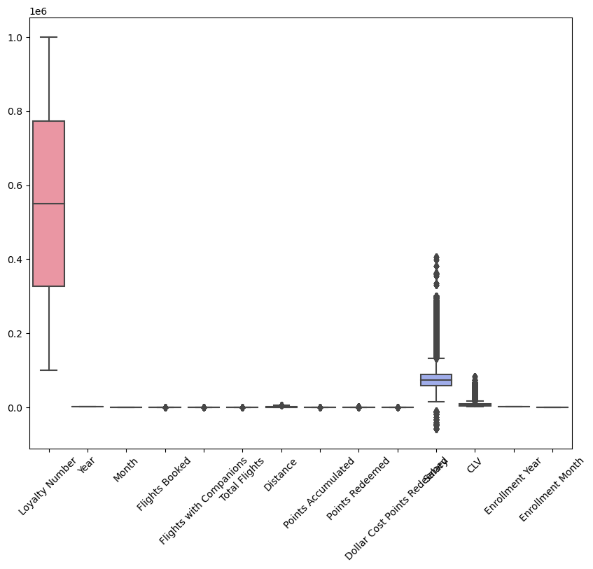

```python
# Create a Box Plot for Numerical Column
plt.figure(figsize=(10,8))
sns.boxplot(data=df1)
plt.xticks(rotation=45)
plt.show()
```

### Hypothesis Testing

```python
import scipy.stats as st
from statsmodels.stats.proportion import proportion_confint,proportions_ztest
```

```python
df1.head()
```

|  | Loyalty Number | Year | Month | Flights Booked | Flights with Companions | Total Flights | Distance | Points Accumulated | Points Redeemed | Dollar Cost Points Redeemed | ... | Postal Code | Gender | Education | Salary | Marital Status | Loyalty Card | CLV | Enrollment Type | Enrollment Year | Enrollment Month |
| --- | --- | --- | --- | --- | --- | --- | --- | --- | --- | --- | --- | --- | --- | --- | --- | --- | --- | --- | --- | --- | --- |
| 0 | 100018 | 2017 | 1 | 3 | 0 | 3 | 1521 | 152.0 | 0 | 0 | ... | T9G 1W3 | Female | Bachelor | 92552.0 | Married | Aurora | 7919.2 | Standard | 2016 | 8 |
| 1 | 100018 | 2017 | 2 | 2 | 2 | 4 | 1320 | 132.0 | 0 | 0 | ... | T9G 1W3 | Female | Bachelor | 92552.0 | Married | Aurora | 7919.2 | Standard | 2016 | 8 |
| 2 | 100018 | 2018 | 10 | 6 | 4 | 10 | 3110 | 311.0 | 385 | 31 | ... | T9G 1W3 | Female | Bachelor | 92552.0 | Married | Aurora | 7919.2 | Standard | 2016 | 8 |
| 3 | 100018 | 2017 | 4 | 4 | 0 | 4 | 924 | 92.0 | 0 | 0 | ... | T9G 1W3 | Female | Bachelor | 92552.0 | Married | Aurora | 7919.2 | Standard | 2016 | 8 |
| 4 | 100018 | 2017 | 5 | 0 | 0 | 0 | 0 | 0.0 | 0 | 0 | ... | T9G 1W3 | Female | Bachelor | 92552.0 | Married | Aurora | 7919.2 | Standard | 2016 | 8 |

5 rows × 23 columns

## Hypothesis: Loyalty Card comparision with Total FLights

### HO: The Loyalty Card does not effect total number of flights taken by a passenger

### H1: The Loyalty Card does effect total number of flights taken by a passenger.

```python
from scipy.stats import chi2_contingency
```

```python
### Create the Contingency Table
contingency_table = pd.crosstab(df1['Loyalty Card'], df1['Total Flights'])
print(contingency_table)
```

```
Total Flights     0     1     2     3     4     5     6     7     8     9   \
Loyalty Card
Aurora         40985  1268  2686  1973  2772  1914  3222  2061  2842  2208
Nova           67466  2000  4368  3305  4590  3157  5153  3335  4743  3543
Star           89541  2838  5978  4505  6294  4238  6898  4477  6471  4937

Total Flights  ...   23   24   25   26   27   28  29  30  31  32
Loyalty Card   ...
Aurora         ...  352  237  178  130  125   69  52  33  16   5
Nova           ...  537  418  307  251  171   98  68  51  17   6
Star           ...  727  554  415  341  208  139  94  66  28  16

[3 rows x 33 columns]
```

```python
### Perform the chi-square test
chi2, p, dof, expected = chi2_contingency(contingency_table)

### Output the results
print(f"Chi-Square Statistics: {chi2}")
print(f"P-Value: {p}")
print(f"Degrees of Freedom: {dof}")
print(f"Expected Frequencies: ")
print(expected)
```

```
Chi-Square Statistics: 65.17981646327854
P-Value: 0.4354452088229432
Degrees of Freedom: 64
Expected Frequencies:
[[4.09198305e+04 1.26195243e+03 2.69337767e+03 2.02189332e+03
  2.82234235e+03 1.92392977e+03 3.15653447e+03 2.04049399e+03
  2.90501201e+03 2.20893344e+03 2.97466120e+03 2.54209218e+03
  2.56461967e+03 2.16987202e+03 2.13081060e+03 1.76582403e+03
  1.59697124e+03 1.28096645e+03 1.18982315e+03 8.27109993e+02
  7.06205609e+02 5.39419561e+02 4.09421514e+02 3.33985445e+02
  2.49869061e+02 1.86006745e+02 1.49218744e+02 1.04163777e+02
  6.32422934e+01 4.42282705e+01 3.10011242e+01 1.26071238e+01
  5.58020235e+00]
 [6.71492896e+04 2.07085924e+03 4.41982273e+03 3.31791941e+03
  4.63145329e+03 3.15716159e+03 5.17986131e+03 3.34844305e+03
  4.76711390e+03 3.62485155e+03 4.88140796e+03 4.17156381e+03
  4.20853133e+03 3.56075191e+03 3.49665227e+03 2.89771067e+03
  2.62062387e+03 2.10206118e+03 1.95249536e+03 1.35728442e+03
  1.15888078e+03 8.85185492e+02 6.71859180e+02 5.48068872e+02
  4.10034199e+02 3.05236377e+02 2.44867404e+02 1.70932371e+02
  1.03780368e+02 7.25784273e+01 5.08727294e+01 2.06882433e+01
  9.15709130e+00]
 [8.99228798e+04 2.77318833e+03 5.91879960e+03 4.44318727e+03
  6.20220437e+03 4.22790864e+03 6.93660422e+03 4.48406295e+03
  6.38387409e+03 4.85421502e+03 6.53693083e+03 5.58634400e+03
  5.63584900e+03 4.76837607e+03 4.68253713e+03 3.88046530e+03
  3.50940489e+03 2.81497237e+03 2.61468150e+03 1.81760559e+03
  1.55191361e+03 1.18539495e+03 8.99719307e+02 7.33945684e+02
  5.49096740e+02 4.08756878e+02 3.27913851e+02 2.28903852e+02
  1.38977339e+02 9.71933022e+01 6.81261464e+01 2.77046329e+01
  1.22627063e+01]]
```

```python
### Decision Based on p-value
alpha = 0.05
if p < alpha:
    print("Reject the Null Hypothesis (HO): The loyalty card does effect total number of flights taken by a passenger")
else:
    print("Fail to Reject the Null Hypothesis (H1): The loyalty card does not effect the total number of flights taken by a passenger")
```

```
Fail to Reject the Null Hypothesis (H1): The loyalty card does not effect the total number of flights taken by a passenger
```

## Hypothesis: Loyalty Card comparision with Flights with Companions

### HO: The Loyalty Card does not significant impact on Flight Booked With Companions

### H1: The Loyalty Card does have significant impact on Flight Booked With Companions

```python
### Create the Contingency Table
contingency_table = pd.crosstab(df1['Loyalty Card'], df1['Flights with Companions'])
print(contingency_table)
```

```
Flights with Companions      0     1     2     3     4     5     6     7   \
Loyalty Card
Aurora                    61434  3658  3938  3936  2889  2717  2026  1456
Nova                     100742  6166  6522  6422  4521  4605  3381  2370
Star                     134711  8081  8812  8657  6255  6102  4504  3263

Flights with Companions    8     9    10   11
Loyalty Card
Aurora                    831   630  198  119
Nova                     1341   995  370  133
Star                     1793  1319  503  224
```

```python
### Perform the chi-square test
chi2, p, dof, expected = chi2_contingency(contingency_table)

### Output the results
print(f"Chi-Square Statistics: {chi2}")
print(f"P-Value: {p}")
print(f"Degrees of Freedom: {dof}")
print(f"Expected Frequencies: ")
print(expected)
```

```
Chi-Square Statistics: 25.522636061746656
P-Value: 0.2727405400844645
Degrees of Freedom: 22
Expected Frequencies:
[[6.13588717e+04 3.70050086e+03 3.98302444e+03 3.92990918e+03
  2.82420241e+03 2.77439394e+03 2.04834761e+03 1.46511313e+03
  8.19463050e+02 6.08448731e+02 2.21348027e+02 9.83769008e+01]
 [1.00689680e+05 6.07250814e+03 6.53612828e+03 6.44896633e+03
  4.63450565e+03 4.55277013e+03 3.36133081e+03 2.40424519e+03
  1.34473581e+03 9.98462103e+02 3.63231288e+02 1.61436128e+02]
 [1.34838448e+05 8.13199101e+03 8.75284729e+03 8.63612449e+03
  6.20629194e+03 6.09683593e+03 4.50132158e+03 3.21964168e+03
  1.80080114e+03 1.33708917e+03 4.86420685e+02 2.16186971e+02]]
```

```python
### Decision Based on p-value
alpha = 0.05
if p < alpha:
    print("Reject the Null Hypothesis (HO): The loyalty card does effect total number of flights booked with companions")
else:
    print("Fail to Reject the Null Hypothesis (H1): The loyalty card does not effect the total number of flights booked with companions")
```

```
Fail to Reject the Null Hypothesis (H1): The loyalty card does not effect the total number of flights booked with companions
```

#### Fail to Reject the Null Hypothesis (H1): The loyalty card does not effect the total number of flights booked with companions

## Hypothesis: Enrollment Type comparison with Total Flights taken by a passenger

### HO: Enrollment type does not have significant impact on Total FLights

### H1: Enrollment Type does have significant impact on Total Flights

```python
### Create the Contingency Table
contingency_table = pd.crosstab(df1['Enrollment Type'], df1['Total Flights'])
print(contingency_table)
```

```
Total Flights        0     1      2     3      4     5      6     7      8   \
Enrollment Type
2018 Promotion    14368   239    557   426    574   413    619   420    607
Standard         183624  5867  12475  9357  13082  8896  14654  9453  13449

Total Flights       9   ...    23    24   25   26   27   28   29   30  31  32
Enrollment Type         ...
2018 Promotion     465  ...    75    54   45   34   21   16   10    8   1   2
Standard         10223  ...  1541  1155  855  688  483  290  204  142  60  25

[2 rows x 33 columns]
```

```python
### Perform the chi-square test
chi2, p, dof, expected = chi2_contingency(contingency_table)

### Output the results
print(f"Chi-Square Statistics: {chi2}")
print(f"P-Value: {p}")
print(f"Degrees of Freedom: {dof}")
print(f"Expected Frequencies: ")
print(expected)
```

```
Chi-Square Statistics: 1587.5903273887961
P-Value: 0.0
Degrees of Freedom: 32
Expected Frequencies:
[[1.14336543e+04 3.52609668e+02 7.52572747e+02 5.64949293e+02
  7.88607538e+02 5.37576711e+02 8.81986155e+02 5.70146619e+02
  8.11706763e+02 6.17211289e+02 8.31167860e+02 7.10301166e+02
  7.16595704e+02 6.06296906e+02 5.95382522e+02 4.93399444e+02
  4.46219277e+02 3.57922490e+02 3.32455594e+02 2.31107745e+02
  1.97325129e+02 1.50722442e+02 1.14398911e+02 9.33208686e+01
  6.98174073e+01 5.19732560e+01 4.16941009e+01 2.91050234e+01
  1.76709070e+01 1.23580853e+01 8.66220934e+00 3.52263180e+00
  1.55919768e+00]
 [1.86558346e+05 5.75339033e+03 1.22794273e+04 9.21805071e+03
  1.28673925e+04 8.77142329e+03 1.43910138e+04 9.30285338e+03
  1.32442932e+04 1.00707887e+04 1.35618321e+04 1.15896988e+04
  1.16924043e+04 9.89270309e+03 9.71461748e+03 8.05060056e+03
  7.28078072e+03 5.84007751e+03 5.42454441e+03 3.77089225e+03
  3.21967487e+03 2.45927756e+03 1.86660109e+03 1.52267913e+03
  1.13918259e+03 8.48026744e+02 6.80305899e+02 4.74894977e+02
  2.88329093e+02 2.01641915e+02 1.41337791e+02 5.74773682e+01
  2.54408023e+01]]
```

```python
### Decision Based on p-value
alpha = 0.05
if p < alpha:
    print("Reject the Null Hypothesis (HO): The Enrollment Type does effect total number of flights taken by a passenger")
else:
    print("Fail to Reject the Null Hypothesis (H1): The Enrollment Type does not effect the total number of flights taken by a passenger")
```

```
Reject the Null Hypothesis (HO): The Enrollment Type does effect total number of flights taken by a passenger
```

#### Reject the Null Hypothesis (HO): The Enrollment Type does effect total number of flights taken by a passenger

## Hypothesis: Enrollment Type comparison with Points Accumulated

### HO: Enrollment Type does not significant impact on Points Accumulated

### H1: Enrollment Type does have significant impact on Points Accumulated

```python
### Create the Contingency Table
contingency_table = pd.crosstab(df1['Enrollment Type'], df1['Points Accumulated'])
print(contingency_table)
```

```
Points Accumulated  0.00    9.00    9.72    10.00   10.80   11.00   11.25   \
Enrollment Type
2018 Promotion       14368       1       0       0       0       0       0
Standard            183624      14       4      17       1      11       1

Points Accumulated  11.88   12.00   12.50   ...  648.00  649.50  655.50  \
Enrollment Type                             ...
2018 Promotion           0       1       0  ...       0       0       0
Standard                 1      12       1  ...       3       1       1

Points Accumulated  658.50  661.50  663.00  666.00  667.50  675.00  676.50
Enrollment Type
2018 Promotion           0       1       0       1       0       0       0
Standard                 1       0       1       1       1       2       1

[2 rows x 1549 columns]
```

```python
### Perform the chi-square test
chi2, p, dof, expected = chi2_contingency(contingency_table)

### Output the results
print(f"Chi-Square Statistics: {chi2}")
print(f"P-Value: {p}")
print(f"Degrees of Freedom: {dof}")
print(f"Expected Frequencies: ")
print(expected)
```

```
Chi-Square Statistics: 2771.3434369988017
P-Value: 2.3500477329707476e-72
Degrees of Freedom: 1548
Expected Frequencies:
[[1.14336543e+04 8.66220934e-01 2.30992249e-01 ... 5.77480622e-02
  1.15496124e-01 5.77480622e-02]
 [1.86558346e+05 1.41337791e+01 3.76900775e+00 ... 9.42251938e-01
  1.88450388e+00 9.42251938e-01]]
```

```python
### Decision Based on p-value
alpha = 0.05
if p < alpha:
    print("Reject the Null Hypothesis (HO): The Enrollment type does effect the points accumulated by a passenger")
else:
    print("Fail to Reject the Null Hypothesis (H1): The Enrollment type does not effect the point accumulated by a passenger ")
```

```
Reject the Null Hypothesis (HO): The Enrollment type does effect the points accumulated by a passenger
```

#### Reject the Null Hypothesis (HO): The Enrollment type does effect the points accumulated by a passenger

### H1: There is no significant difference between Customer Lifetime value(CLV) and Education Level of Passenger

```python
from statsmodels.formula.api import ols
from statsmodels.stats.anova import anova_lm
```

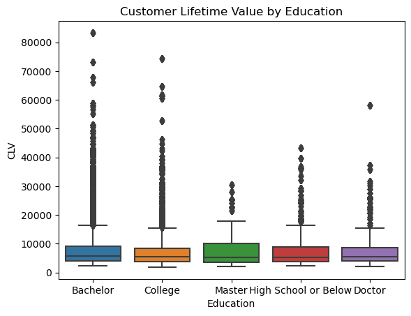

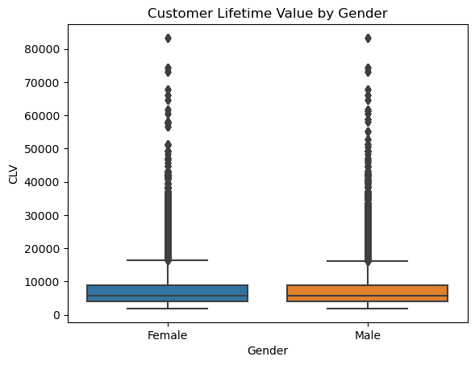

```python
### Exploratory Data Analysis
sns.boxplot(x='Education',y='CLV',data = df1)
plt.title('Customer Lifetime Value by Education')
plt.show()

sns.boxplot(x='Gender',y='CLV',data = df1)
plt.title('Customer Lifetime Value by Gender')
plt.show()
```

```python
### Perform ANOVA for Education
model_education = ols('CLV ~ C(Education)',data=df1).fit()
anova_education = anova_lm(model_education)
print(anova_education)
```

```
                    df        sum_sq       mean_sq           F         PR(>F)
C(Education)       4.0  3.515773e+10  8.789432e+09  186.915068  2.344860e-160
Residual      405619.0  1.907369e+13  4.702367e+07         NaN            NaN
```

```python
# Ensure the dependent variable is numeric
if not np.issubdtype(df1['CLV'].dtype, np.number):
    raise TypeError("LoyaltyScore should be a numeric variable")
```

```python
# Convert categorical variables to type 'category' if not already
categorical_columns = ['Education', 'Marital Status']
for col in categorical_columns:
    if df1[col].dtype != 'category':
        df1[col] = df1[col].astype('category')
```

```python
### Perform ANOVA for Gender
model_gender = ols('CLV ~ C(Gender)',data=df1).fit()
anova_gender = anova_lm(model_education)
print(anova_gender)
```

```
                    df        sum_sq       mean_sq           F         PR(>F)
C(Education)       4.0  3.515773e+10  8.789432e+09  186.915068  2.344860e-160
Residual      405619.0  1.907369e+13  4.702367e+07         NaN            NaN
```

```python
# Interpretation of results
alpha = 0.05
print("ANOVA Results for Education:")
if anova_education['PR(>F)'][0] < alpha:
    print("There is a significant difference in Customer Lifetime Value based on Education.")
else:
    print("There is no significant difference in Customer Lifetime Value based on Education.")

print("\nANOVA Results for Gender:")
if anova_gender['PR(>F)'][0] < alpha:
    print("There is a significant difference in Customer Lifetime Value based on Gender.")
else:
    print("There is no significant difference in Customer Lifetime Value based on Gender.")
```

[output not shown]

## Visualization

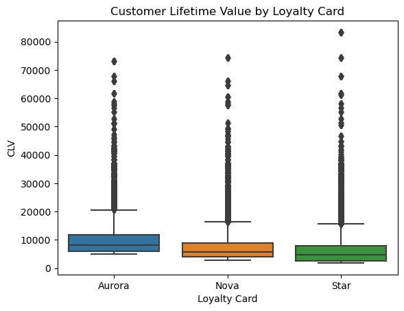

```python
sns.boxplot(x='Loyalty Card',y = 'CLV', data = df1)
plt.title('Customer Lifetime Value by Loyalty Card')
plt.show()
```

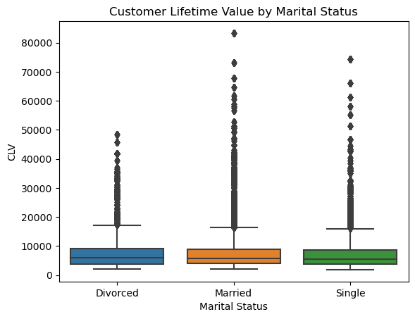

```python
sns.boxplot(x='Marital Status',y = 'CLV', data = df1)
plt.title('Customer Lifetime Value by Marital Status')
plt.show()
```

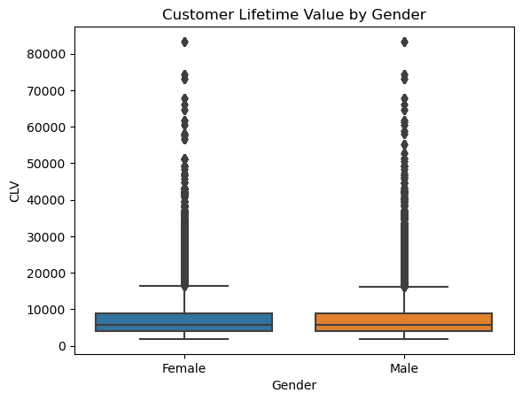

```python
sns.boxplot(x='Gender',y = 'CLV', data = df1)
plt.title('Customer Lifetime Value by Gender')
plt.show()
```

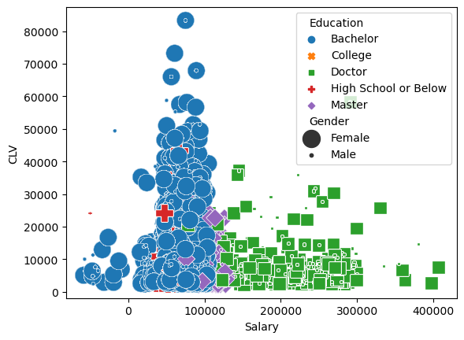

```python
sns.scatterplot(x='Salary', y='CLV', data=df1, hue='Education', style='Education', size='Gender', sizes=(10, 250))
```

```python
df1.info()
```

```
<class 'pandas.core.frame.DataFrame'>
Int64Index: 405624 entries, 0 to 405623
Data columns (total 23 columns):
 #   Column                       Non-Null Count   Dtype
---  ------                       --------------   -----
 0   Loyalty Number               405624 non-null  int64
 1   Year                         405624 non-null  int64
 2   Month                        405624 non-null  int64
 3   Flights Booked               405624 non-null  int64
 4   Flights with Companions      405624 non-null  int64
 5   Total Flights                405624 non-null  int64
 6   Distance                     405624 non-null  int64
 7   Points Accumulated           405624 non-null  float64
 8   Points Redeemed              405624 non-null  int64
 9   Dollar Cost Points Redeemed  405624 non-null  int64
 10  Country                      405624 non-null  object
 11  Province                     405624 non-null  object
 12  City                         405624 non-null  object
 13  Postal Code                  405624 non-null  object
 14  Gender                       405624 non-null  object
 15  Education                    405624 non-null  category
 16  Salary                       302952 non-null  float64
 17  Marital Status               405624 non-null  category
 18  Loyalty Card                 405624 non-null  object
 19  CLV                          405624 non-null  float64
 20  Enrollment Type              405624 non-null  object
 21  Enrollment Year              405624 non-null  int64
 22  Enrollment Month             405624 non-null  int64
dtypes: category(2), float64(3), int64(11), object(7)
memory usage: 68.9+ MB
```

```python
from scipy import stats
```

```python
### Identifying Outliers

# Calculate the Z-scores for each column
z_scores = np.abs(stats.zscore(df1.select_dtypes(include=np.number)))

# Identify outliers with Z-score > 3
outliers_z = df1[(z_scores > 3).any(axis=1)]
print("Outliers based on Z-score:")
print(outliers_z)
```

```
Outliers based on Z-score:
        Loyalty Number  Year  Month  Flights Booked  Flights with Companions  \
8               100018  2017      8              10                        5
13              100018  2017      3              14                        3
30              100102  2017     12              11                        3
43              100102  2018      9               8                        8
45              100102  2017      3              15                        4
...                ...   ...    ...             ...                      ...
405516          998972  2017     12              11                        1
405525          998972  2017      9               5                        1
405546          999304  2017      6              12                        3
405567          999731  2017     11               2                        2
405603          999891  2017      1               1                        1

        Total Flights  Distance  Points Accumulated  Points Redeemed  \
```

[output cut: 52 more lines]

```python
### Method 2: Interquartile Range

def find_outliers_iqr(df1):
    outliers = pd.DataFrame(columns=df1.columns)
    for col in df1.select_dtypes(include=np.number).columns:

        Q1 = df1[col].quantile(0.25)
        Q3 = df1[col].quantile(0.75)
        IQR = Q3-Q1
        lower_bound = Q1 - 1.5*IQR
        upper_bound = Q3 + 1.5*IQR
        col_outliers = df1[(df1[col] < lower_bound) | (df1[col] > upper_bound)]
        outliers = pd.concat([outliers, col_outliers])
    return outliers.drop_duplicates()
# Identify Outliers using IQR
outliers_iqr = find_outliers_iqr(df1)
print("Outliers based on IQR")
print(outliers_iqr)
```

```
Outliers based on IQR
       Loyalty Number  Year Month Flights Booked Flights with Companions  \
1050           102184  2018     7             21                       7
2070           104586  2017     7             21                       0
2106           104673  2018     7             21                       0
2201           104960  2018     7             21                       0
2622           105992  2017     7             21                       0
...               ...   ...   ...            ...                     ...
404490         969719  2018     8              0                       0
404492         969719  2018     9              0                       0
404493         969719  2018    10              0                       0
404494         969719  2018    11              0                       0
404495         969719  2018    12              0                       0

       Total Flights Distance  Points Accumulated Points Redeemed  \
```

[output cut: 52 more lines]

### Boxplot for Each Numerical Column

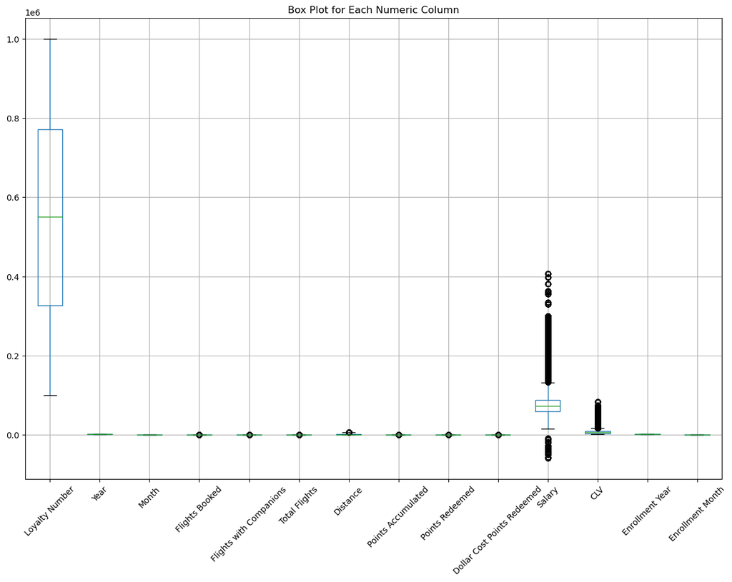

```python
# Box plot for each numeric column
plt.figure(figsize=(15, 10))
df1.select_dtypes(include=np.number).boxplot()
plt.xticks(rotation=45)
plt.title("Box Plot for Each Numeric Column")
plt.show()
```

[output not shown]

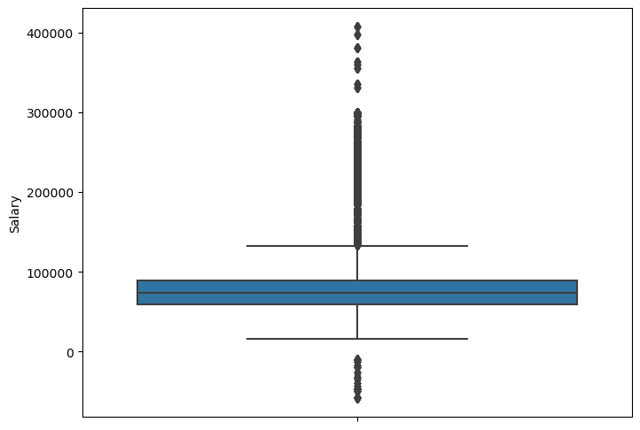

```python
### Outliers Visualzation
#### Salary

plt.figure(figsize=(8, 6))
sns.boxplot(y=df1['Salary'])
plt.title(f'Box Plot for {Salary}')
plt.show()
```

### Outliers Visualzation

```python
df2_c = df1.copy(deep=True)
```

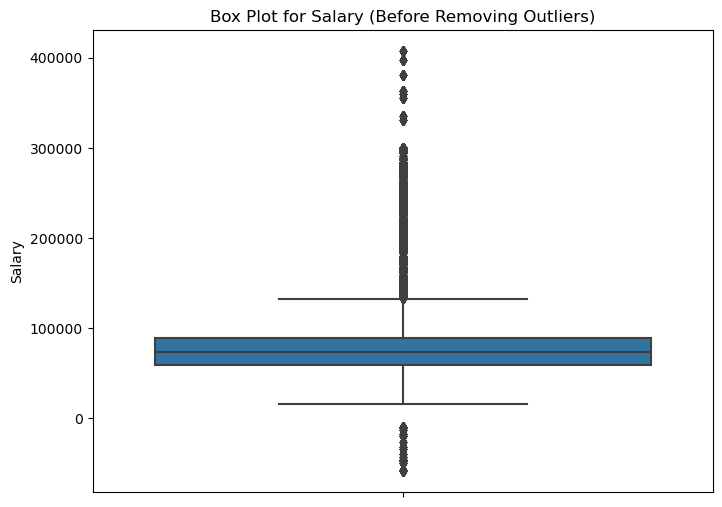

[figure not shown]

```python
def visualize_box_plot(data, column, title):
    plt.figure(figsize=(8, 6))
    sns.boxplot(y=data[column])
    plt.title(title)
    plt.show()

def remove_outliers_z_score(data, column, threshold=3):
    z_scores = stats.zscore(data[column])
    abs_z_scores = abs(z_scores)
    filtered_entries = (abs_z_scores < threshold)
    return data[filtered_entries]

# Visualize box plot before removing outliers
visualize_box_plot(df1, 'Salary', 'Box Plot for Salary (Before Removing Outliers)')

# Remove outliers using Z-score method
df1_c = remove_outliers_z_score(df1, 'Salary')

# Visualize box plot after removing outliers
visualize_box_plot(df2_c, 'Salary', 'Box Plot for Salary (After Removing Outliers - Z-score)')
```

## Encoding and Model Building

```python
df3_c = df1.copy(deep=True)
```

```python
from sklearn.preprocessing import OneHotEncoder, StandardScaler
from sklearn.compose import ColumnTransformer
from sklearn.pipeline import Pipeline
```

```python
### Download Diffrent Library for Model Building
from sklearn.model_selection import train_test_split, GridSearchCV
from sklearn.linear_model import LogisticRegression
from sklearn.metrics import accuracy_score, confusion_matrix, classification_report
from sklearn.metrics import roc_auc_score
```

```python
df3_c.head()
```

|  | Loyalty Number | Year | Month | Flights Booked | Flights with Companions | Total Flights | Distance | Points Accumulated | Points Redeemed | Dollar Cost Points Redeemed | ... | Postal Code | Gender | Education | Salary | Marital Status | Loyalty Card | CLV | Enrollment Type | Enrollment Year | Enrollment Month |
| --- | --- | --- | --- | --- | --- | --- | --- | --- | --- | --- | --- | --- | --- | --- | --- | --- | --- | --- | --- | --- | --- |
| 0 | 100018 | 2017 | 1 | 3 | 0 | 3 | 1521 | 152.0 | 0 | 0 | ... | T9G 1W3 | Female | Bachelor | 92552.0 | Married | Aurora | 7919.2 | Standard | 2016 | 8 |
| 1 | 100018 | 2017 | 2 | 2 | 2 | 4 | 1320 | 132.0 | 0 | 0 | ... | T9G 1W3 | Female | Bachelor | 92552.0 | Married | Aurora | 7919.2 | Standard | 2016 | 8 |
| 2 | 100018 | 2018 | 10 | 6 | 4 | 10 | 3110 | 311.0 | 385 | 31 | ... | T9G 1W3 | Female | Bachelor | 92552.0 | Married | Aurora | 7919.2 | Standard | 2016 | 8 |
| 3 | 100018 | 2017 | 4 | 4 | 0 | 4 | 924 | 92.0 | 0 | 0 | ... | T9G 1W3 | Female | Bachelor | 92552.0 | Married | Aurora | 7919.2 | Standard | 2016 | 8 |
| 4 | 100018 | 2017 | 5 | 0 | 0 | 0 | 0 | 0.0 | 0 | 0 | ... | T9G 1W3 | Female | Bachelor | 92552.0 | Married | Aurora | 7919.2 | Standard | 2016 | 8 |

5 rows × 23 columns

```python
### Identify Categorical and Numerical Column

categorical_features = ['Education', 'Marital Status','Enrollment Type','Gender']
numerical_features = ['Month','Flights Booked','Flights with Companions','Total Flights','Distance','Points Accumulated','Points Redeemed','Enrollment Year','Enrollment Month']
```

```python
### Check for missing values
print(df3_c.isnull().sum())
```

```
Loyalty Number                      0
Year                                0
Month                               0
Flights Booked                      0
Flights with Companions             0
Total Flights                       0
Distance                            0
Points Accumulated                  0
Points Redeemed                     0
Dollar Cost Points Redeemed         0
Country                             0
Province                            0
City                                0
Postal Code                         0
Gender                              0
Education                           0
Salary                         102672
Marital Status                      0
Loyalty Card                        0
CLV                                 0
Enrollment Type                     0
Enrollment Year                     0
Enrollment Month                    0
dtype: int64
```

### Separate feature and target

```python
### Separate feature and target

X = df3_c[categorical_features + numerical_features]
y = df3_c['Loyalty Card']
```

```python
# Encoding Data with One-Hot-Encoding with ColumnTransformer for preprocessing
preprocessor = ColumnTransformer(
    transformers=[
        ('cat', OneHotEncoder(handle_unknown='ignore'), categorical_features),
        ('num', StandardScaler(), numerical_features)
    ],
    remainder='passthrough'
)
```

```python
### Split the data into training and testing sets

X_train,X_test,y_train,y_test = train_test_split(X,y, test_size=0.2,random_state = 42)
```

```python
### Create a Pipeline with Preprocessing and Model
pipeline = Pipeline(steps=[
    ('preprocessor', preprocessor),
    ('model', LogisticRegression(penalty = 'l1',multi_class = 'ovr',solver = 'liblinear',max_iter=1000))

])
```

```python
### Fit the Pipeline on the Training Data

pipeline.fit(X_train,y_train)
```

```
Pipeline(steps=[('preprocessor',
                 ColumnTransformer(remainder='passthrough',
                                   transformers=[('cat',
                                                  OneHotEncoder(handle_unknown='ignore'),
                                                  ['Education',
                                                   'Marital Status',
                                                   'Enrollment Type',
                                                   'Gender']),
                                                 ('num', StandardScaler(),
                                                  ['Month', 'Flights Booked',
                                                   'Flights with Companions',
                                                   'Total Flights', 'Distance',
                                                   'Points Accumulated',
                                                   'Points Redeemed',
                                                   'Enrollment Year',
                                                   'Enrollment Month'])])),
                ('model',
                 LogisticRegression(max_iter=1000, multi_class='ovr',
                                    penalty='l1', solver='liblinear'))])
```

```python
### Make Predictions on the test data
y_pred = pipeline.predict(X_test)
```

```python
### Extract feature names after preprocessing

feature_names = np.array(preprocessor.transformers_[0][1].get_feature_names_out(categorical_features))
feature_names = np.append(feature_names,numerical_features)
```

```python
### Retrieve coefficients from the logistic Regression Model

coefficients = pipeline.named_steps['model'].coef_[0]
```

```python
### Create a Dataframe to display feature importance

feature_importance = ({
    'Feature' : feature_names,
    'Coefficient' : coefficients

})
```

```python
### Display the Feature importance

print(feature_importance)
```

```
{'Feature': array(['Education_Bachelor', 'Education_College', 'Education_Doctor',
       'Education_High School or Below', 'Education_Master',
       'Marital Status_Divorced', 'Marital Status_Married',
       'Marital Status_Single', 'Enrollment Type_2018 Promotion',
       'Enrollment Type_Standard', 'Gender_Female', 'Gender_Male',
       'Month', 'Flights Booked', 'Flights with Companions',
       'Total Flights', 'Distance', 'Points Accumulated',
       'Points Redeemed', 'Enrollment Year', 'Enrollment Month'],
      dtype=object), 'Coefficient': array([ 8.11034522e-02, -7.59883050e-02, -1.59954277e-01, -1.89984741e-01,
       -2.82860103e-01, -1.23001960e-01, -7.96001487e-02, -1.94315386e-01,
       -1.05638386e+00, -1.14940960e+00, -2.66285260e-02, -8.68754793e-03,
        6.26576848e-02,  1.16150568e-02,  7.98463100e-03,  1.40703551e-02,
       -2.46778277e+00,  2.43985133e+00,  2.20115738e-04, -1.35476651e-02,
        3.81199311e-03])}
```

from sklearn.feature_selection import RFE

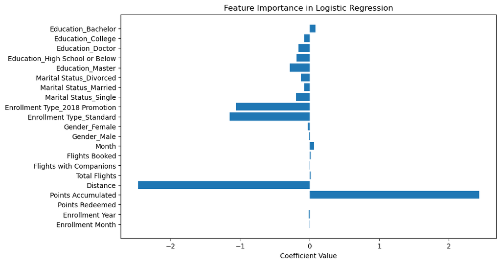

```python
# Plot feature importance
plt.figure(figsize=(10, 6))
plt.barh(feature_importance['Feature'], feature_importance['Coefficient'])
plt.xlabel('Coefficient Value')
plt.title('Feature Importance in Logistic Regression')
plt.gca().invert_yaxis()  # Invert y-axis to show the highest importance at the top
plt.show()
```

```python
### Evaluate the Model

accuracy = accuracy_score(y_test,y_pred)
print(f'Accuracy: {accuracy}')

conf_matrix = confusion_matrix(y_test,y_pred)
print('Confusion Matrix: ')
print(conf_matrix)

class_report = classification_report(y_test,y_pred)
print('Classifiation Report: ')
print(class_report)
```

```
Accuracy: 0.4659106317411402
Confusion Matrix:
[[  857   167 15846]
 [  750   818 25958]
 [    0   607 36122]]
Classifiation Report:
              precision    recall  f1-score   support

      Aurora       0.53      0.05      0.09     16870
        Nova       0.51      0.03      0.06     27526
        Star       0.46      0.98      0.63     36729

    accuracy                           0.47     81125
   macro avg       0.50      0.35      0.26     81125
weighted avg       0.50      0.47      0.32     81125
```

```python
### Estimate the probability
y_pred_proba = pipeline.predict_proba(X_test)[:,1] ## Probability estimate for positive class
```

```python
### Calculate the Roc_Auc_Score
roc_auc = roc_auc_score(y_test, y_pred_proba)
print(f'Roc_Auc_Score: {roc_auc}')
```

[output not shown]

```python
### Check Data Types
print(X_train.dtypes)
print(X_test.dtypes)
```

[output not shown]